# March Madness 2026 — NCAA Tournament Prediction Pipeline

**Competition:** [March Machine Learning Mania 2026](https://www.kaggle.com/competitions/march-machine-learning-mania-2026)  
**Objective:** Predict the probability that Team 1 beats Team 2 for every possible matchup in both the Men's and Women's 2026 NCAA basketball tournaments.  
**Metric:** Mean Squared Error (Brier score) — lower is better. Overconfident wrong predictions are heavily penalized.  
**Submission format:** `ID,Pred` where `ID = Season_Team1ID_Team2ID` (Team1ID < Team2ID) and `Pred ∈ [0, 1]`.

### Pipeline Overview

This notebook runs **end-to-end** — from downloading raw data to generating a submission CSV:

[output not shown]

### Key Findings (from 25+ experiments)

```
Libraries loaded.
```

## Step 0: Download Latest Data from Kaggle

Every run starts by pulling the latest competition data. This ensures we always have the most recent regular season results, tournament outcomes, and submission templates. The Kaggle CLI must be installed and authenticated (`~/.kaggle/kaggle.json`).

> **Note:** If data was recently downloaded and hasn't changed, this step completes quickly.

```
Downloading latest data from Kaggle (march-machine-learning-mania-2026)...
You must authenticate before you can call the Kaggle API.
Follow the instructions to authenticate at: https://github.com/Kaggle/kaggle-cli/blob/main/docs/README.md#authentication
⚠️  Kaggle download failed (exit 1):
Continuing with existing local data...
  ✓  MRegularSeasonDetailedResults.csv
  ✓  WRegularSeasonDetailedResults.csv
  ✓  MNCAATourneyDetailedResults.csv
  ✓  WNCAATourneyDetailedResults.csv
  ✓  MNCAATourneySeeds.csv
  ✓  WNCAATourneySeeds.csv
  ✓  MMasseyOrdinals.csv
  ✓  SampleSubmissionStage2.csv

Total CSV files: 35
```

## Experiment Tracker

Every model variant we try gets logged here. We track MSE on **three holdout years** (2023, 2024, 2025) so we can see if an improvement is real or just got lucky on one year. A change only counts as an improvement if it helps on **at least 2 of 3** holdout years.

**Why three years?** With only ~130 tournament games per year, a single holdout year can be noisy — one fluky upset can swing MSE by 0.01+. Three-year validation smooths this out.

```
Holdout validation years: [2023, 2024, 2025]
```

## Step 1: Load Data & Engineer Features

```
Raw game data (W/L format)
  → prepare_game_data()          # Convert to symmetric T1/T2 rows (2 rows per game)
  → compute_season_stats()       # Per-game averages: FGM, TO, Rebounds, etc.
  → compute_win_pct()            # Season record
  → compute_efficiency()         # Points per possession (pace-independent)
  → compute_last14_momentum()    # Late-season form
  → build_team_features()        # Merge all into one table keyed on (Season, TeamID)
  → create_matchup_df()          # Join features for both teams in each matchup
  → compute_difference_features() # Diff_X = T1_X − T2_X (what the model sees)
```

We filter to **2010+ seasons** because women's detailed stats start in 2010, and we **skip 2020** (COVID cancellation).

```
Game data: 327,414 rows
Teams per season: ~704
Seasons: [np.int64(2010), np.int64(2011), np.int64(2012), np.int64(2013), np.int64(2014), np.int64(2015), np.int64(2016), np.int64(2017), np.int64(2018), np.int64(2019), np.int64(2021), np.int64(2022), np.int64(2023), np.int64(2024), np.int64(2025), np.int64(2026)]
```

```
  2023: 134 tournament games
  2024: 134 tournament games
  2025: 134 tournament games
  Total: 1962 games
```

### Data Exploration — What Are We Working With?

Let's understand the scale and structure of the data before engineering features. Key questions:

- How many teams, games, seasons?
- How does the training data break down between men's and women's games?
- What does the tournament target variable (T1_Win) look like?

```
============================================================
  DATA OVERVIEW
============================================================

Regular Season Games:
  Men's:   122,775 games (24 seasons)
  Women's: 85,505 games (17 seasons)

Tournament Games (training set):
  Men's:   1001 games
  Women's: 961 games
  Total:   1962 games ← THIS is what we train on
  ⚠️  Only ~122 games/year — very small!

Target (T1_Win): 51.0% win rate
  (Should be ~50% since T1/T2 are ordered by ID, not strength)

Seasons used: [np.int64(2010), np.int64(2011), np.int64(2012), np.int64(2013), np.int64(2014), np.int64(2015), np.int64(2016), np.int64(2017), np.int64(2018), np.int64(2019), np.int64(2021), np.int64(2022), np.int64(2023), np.int64(2024), np.int64(2025)]
Holdout years: [2023, 2024, 2025]
```

## Step 2: Multi-Year Holdout Validation Framework

The core idea: **don't trust a single holdout year**. A model that looks great on 2025 alone may have gotten lucky.

Our validation protocol:

1. **Pick a holdout year** (e.g., 2025)
2. **Train on all years before it** (2010–2024, excluding 2020 COVID cancellation)
3. **Predict and evaluate** on the holdout year's tournament games
4. **Evaluate on holdout year** — measure MSE on tournament predictions
5. **Repeat for 2023, 2024, 2025** — average MSE across all three

This gives us a reliable estimate of generalization, not just a lucky year.

Two experiment runners are defined below:

- **`run_experiment()`** — trains a single model on all data (combined M+W or filtered)
- **`run_split_experiment()`** — trains separate men's and women's models, combines predictions

```
Experiment runner ready.
```

```
Split experiment runner ready.
```

## Step 3: Run Experiments

### Experiment 1: Seed-Only Baseline

How well can we do with **just seed difference**? This is the floor — if we can't beat this, our features aren't adding value. The NCAA selection committee already considers record, strength of schedule, and eye-test when assigning seeds, so seed difference is a surprisingly strong predictor on its own.

```
============================================================
  Experiment: Seed Only (LR)
  LogReg on Diff_seed only
============================================================
  2023: MSE=0.190180, Acc=69.4%  (134 games)
  2024: MSE=0.164201, Acc=76.1%  (134 games)
  2025: MSE=0.143248, Acc=79.9%  (134 games)
  Average MSE: 0.165876
============================================================
```

```
{2023: {'mse': 0.19017996355932132,
  'accuracy': np.float64(0.6940298507462687),
  'n_games': 134},
 2024: {'mse': 0.16420080867126471,
  'accuracy': np.float64(0.7611940298507462),
  'n_games': 134},
 2025: {'mse': 0.14324773615606862,
  'accuracy': np.float64(0.7985074626865671),
  'n_games': 134}}
```

## Experiment 2: Core Features (What Won Phase 1)

The logistic regression feature importance showed **seed + point diff + offensive efficiency + win %** as the big 4. Let's test combinations to see which subset is best.

```
============================================================
  Experiment: Top4 (LR)
  LogReg on seed + PointDiff + OffEff + WinPct
============================================================
  2023: MSE=0.181327, Acc=73.9%  (134 games)
  2024: MSE=0.166476, Acc=73.9%  (134 games)
  2025: MSE=0.139637, Acc=83.6%  (134 games)
  Average MSE: 0.162480
============================================================
```

```
{2023: {'mse': 0.18132729506271003,
  'accuracy': np.float64(0.7388059701492538),
  'n_games': 134},
 2024: {'mse': 0.16647605830090106,
  'accuracy': np.float64(0.7388059701492538),
  'n_games': 134},
 2025: {'mse': 0.13963727017279837,
  'accuracy': np.float64(0.835820895522388),
  'n_games': 134}}
```

```
============================================================
  Experiment: Top6 (LR)
  LogReg on top4 + DefEff + momentum
============================================================
  2023: MSE=0.181954, Acc=73.9%  (134 games)
  2024: MSE=0.166526, Acc=74.6%  (134 games)
  2025: MSE=0.139167, Acc=83.6%  (134 games)
  Average MSE: 0.162549
============================================================
```

```
{2023: {'mse': 0.18195423916334635,
  'accuracy': np.float64(0.7388059701492538),
  'n_games': 134},
 2024: {'mse': 0.16652566358195933,
  'accuracy': np.float64(0.746268656716418),
  'n_games': 134},
 2025: {'mse': 0.13916741165934132,
  'accuracy': np.float64(0.835820895522388),
  'n_games': 134}}
```

```
============================================================
  Experiment: All Diff (LR)
  LogReg on all 20 diff features
============================================================
  2023: MSE=0.188309, Acc=73.1%  (134 games)
  2024: MSE=0.169386, Acc=71.6%  (134 games)
  2025: MSE=0.144699, Acc=81.3%  (134 games)
  Average MSE: 0.167465
============================================================
```

```
{2023: {'mse': 0.18830898749603533,
  'accuracy': np.float64(0.7313432835820896),
  'n_games': 134},
 2024: {'mse': 0.16938638528740696,
  'accuracy': np.float64(0.7164179104477612),
  'n_games': 134},
 2025: {'mse': 0.1446993871641639,
  'accuracy': np.float64(0.8134328358208955),
  'n_games': 134}}
```

## Experiment 3: XGBoost & LightGBM (Shallow & Constrained)

The lesson from Phase 1 was that XGBoost overfits with default settings. With only ~1,900 total tournament games and ~130 per year, gradient boosting has very limited signal to work with. Let's constrain it aggressively:

- **max_depth=2** (very shallow — can only learn simple interactions like "seed × point diff")
- **min_child_weight=30** (need 30+ samples per leaf — prevents fitting to noise)
- **Only top 4-6 features** (less room to overfit)

The idea: use tree models' ability to find non-linear interactions (e.g., seed matters more when point differentials are close), but don't give them enough rope to hang themselves.

```
============================================================
  Experiment: Top4 (XGB shallow)
  XGBoost depth=2, min_child=30 on top4
============================================================
  2023: MSE=0.182052, Acc=70.9%  (134 games)
  2024: MSE=0.160572, Acc=73.9%  (134 games)
  2025: MSE=0.143740, Acc=82.1%  (134 games)
  Average MSE: 0.162121
============================================================
```

```
{2023: {'mse': 0.18205226957798004,
  'accuracy': np.float64(0.7089552238805971),
  'n_games': 134},
 2024: {'mse': 0.16057217121124268,
  'accuracy': np.float64(0.7388059701492538),
  'n_games': 134},
 2025: {'mse': 0.14373955130577087,
  'accuracy': np.float64(0.8208955223880597),
  'n_games': 134}}
```

```
============================================================
  Experiment: Top6 (XGB shallow)
  XGBoost depth=2, min_child=30 on top6
============================================================
  2023: MSE=0.183086, Acc=72.4%  (134 games)
  2024: MSE=0.159119, Acc=74.6%  (134 games)
  2025: MSE=0.142754, Acc=80.6%  (134 games)
  Average MSE: 0.161653
============================================================
```

```
{2023: {'mse': 0.1830863654613495,
  'accuracy': np.float64(0.7238805970149254),
  'n_games': 134},
 2024: {'mse': 0.15911850333213806,
  'accuracy': np.float64(0.746268656716418),
  'n_games': 134},
 2025: {'mse': 0.1427539438009262,
  'accuracy': np.float64(0.8059701492537313),
  'n_games': 134}}
```

```
Training until validation scores don't improve for 50 rounds
Early stopping, best iteration is:
[238]	valid_0's binary_logloss: 0.538348
Training until validation scores don't improve for 50 rounds
Early stopping, best iteration is:
[239]	valid_0's binary_logloss: 0.486295
Training until validation scores don't improve for 50 rounds
Did not meet early stopping. Best iteration is:
[498]	valid_0's binary_logloss: 0.436246

============================================================
  Experiment: Top6 (LGBM shallow)
  LightGBM depth=2, min_child=30 on top6
============================================================
  2023: MSE=0.182140, Acc=73.1%  (134 games)
  2024: MSE=0.162536, Acc=73.9%  (134 games)
  2025: MSE=0.143271, Acc=79.9%  (134 games)
  Average MSE: 0.162649
============================================================
```

```
{2023: {'mse': 0.18213990260864635,
  'accuracy': np.float64(0.7313432835820896),
  'n_games': 134},
 2024: {'mse': 0.1625364330535013,
  'accuracy': np.float64(0.7388059701492538),
  'n_games': 134},
 2025: {'mse': 0.14327054819045776,
  'accuracy': np.float64(0.7985074626865671),
  'n_games': 134}}
```

### Experiment 4: GLM Team Quality

We fit a regularized logistic regression with team indicators on regular season game outcomes (restricted to tournament-eligible teams). The resulting coefficients measure each team's "quality" — essentially a simplified Elo/power rating. Z-score normalized so values range ~[-3, +3].

**Previous bug:** Without L2 regularization, coefficients exploded to 1e16. Now fixed with `alpha=0.1, L1_wt=0.0`.

```
Computing GLM team quality (regularized)...
Quality range: [-2.61, 4.95]
Quality std: 1.00 (should be ~1.0 if z-scored)

Top 5 quality (2024): ['South Carolina', 'Purdue', 'Iowa', 'LSU', 'Houston']

Top 5 quality (2025): ['UCLA', 'South Carolina', 'Auburn', 'Texas', 'USC']
```

```
============================================================
  Experiment: Top4+Quality (LR)
  LogReg on seed + PointDiff + OffEff + WinPct + quality
============================================================
  2023: MSE=0.184646, Acc=73.1%  (134 games)
  2024: MSE=0.165846, Acc=74.6%  (134 games)
  2025: MSE=0.137555, Acc=84.3%  (134 games)
  Average MSE: 0.162682
============================================================
```

```
{2023: {'mse': 0.18464569332065714,
  'accuracy': np.float64(0.7313432835820896),
  'n_games': 134},
 2024: {'mse': 0.1658459636728331,
  'accuracy': np.float64(0.746268656716418),
  'n_games': 134},
 2025: {'mse': 0.13755506130324935,
  'accuracy': np.float64(0.8432835820895522),
  'n_games': 134}}
```

```
============================================================
  Experiment: Top4+Quality (XGB)
  XGBoost depth=2 on top4 + quality
============================================================
  2023: MSE=0.183022, Acc=72.4%  (134 games)
  2024: MSE=0.158927, Acc=75.4%  (134 games)
  2025: MSE=0.144645, Acc=78.4%  (134 games)
  Average MSE: 0.162198
============================================================
```

```
{2023: {'mse': 0.1830216348171234,
  'accuracy': np.float64(0.7238805970149254),
  'n_games': 134},
 2024: {'mse': 0.1589270979166031,
  'accuracy': np.float64(0.753731343283582),
  'n_games': 134},
 2025: {'mse': 0.14464546740055084,
  'accuracy': np.float64(0.7835820895522388),
  'n_games': 134}}
```

### Experiment 5: Massey Ordinals (Men-Only, Properly Handled)

Massey Ordinals are 3rd-party computer rankings (POM, SAG, MOR, DOL, COL). They're **only available for men's teams** — Kaggle doesn't provide them for women.

**Previous bug:** Filling women's missing Massey values with 0 misled the model (0 = "worst team" rather than "unknown"). We now handle this by:

1. Computing Massey features only where available
2. Testing men-only models with Massey
3. Testing combined models where NaN→0 (to see if it still hurts)

```
Loading Massey Ordinals...
Massey features: (8355, 7)

Massey diff features: ['Diff_Massey_COL', 'Diff_Massey_DOL', 'Diff_Massey_MOR', 'Diff_Massey_POM', 'Diff_Massey_SAG']
Men's games with Massey: 100.0%
Women's games with Massey: 0.0%
```

```
============================================================
  Experiment: Top4+Q+Massey (LR)
  LogReg on top4 + quality + all massey (NaN=0)
============================================================
  2023: MSE=0.186185, Acc=73.1%  (134 games)
  2024: MSE=0.165301, Acc=75.4%  (134 games)
  2025: MSE=0.137161, Acc=84.3%  (134 games)
  Average MSE: 0.162882
============================================================
```

```
{2023: {'mse': 0.18618486644135868,
  'accuracy': np.float64(0.7313432835820896),
  'n_games': 134},
 2024: {'mse': 0.16530061424773623,
  'accuracy': np.float64(0.753731343283582),
  'n_games': 134},
 2025: {'mse': 0.13716149795985963,
  'accuracy': np.float64(0.8432835820895522),
  'n_games': 134}}
```

```
Men's tournament games: 1001
Women's tournament games: 961

============================================================
  Experiment: Men Top4+Q+Massey (LR)
  LogReg on top4 + quality + massey (men only)
============================================================
  2023: MSE=0.209355, Acc=70.1%  (67 games)
  2024: MSE=0.203494, Acc=71.6%  (67 games)
  2025: MSE=0.165678, Acc=80.6%  (67 games)
  Average MSE: 0.192842
============================================================
```

```
{2023: {'mse': 0.20935484659558495,
  'accuracy': np.float64(0.7014925373134329),
  'n_games': 67},
 2024: {'mse': 0.20349410952096486,
  'accuracy': np.float64(0.7164179104477612),
  'n_games': 67},
 2025: {'mse': 0.16567792138790166,
  'accuracy': np.float64(0.8059701492537313),
  'n_games': 67}}
```

```
============================================================
  Experiment: Women Top4+Q (LR)
  LogReg on top4 + quality (women only)
============================================================
  2023: MSE=0.170400, Acc=77.6%  (67 games)
  2024: MSE=0.119802, Acc=83.6%  (67 games)
  2025: MSE=0.114894, Acc=86.6%  (67 games)
  Average MSE: 0.135032
============================================================
```

```
{2023: {'mse': 0.17039993294506348,
  'accuracy': np.float64(0.7761194029850746),
  'n_games': 67},
 2024: {'mse': 0.11980196909357314,
  'accuracy': np.float64(0.835820895522388),
  'n_games': 67},
 2025: {'mse': 0.11489392527273576,
  'accuracy': np.float64(0.8656716417910447),
  'n_games': 67}}
```

### Interim Leaderboard (Experiments 1–5)

Let's see where we stand before exploring additional features.

```
================================================================================
  EXPERIMENT LEADERBOARD (sorted by avg MSE, lower = better)
================================================================================
                  name                                            description  MSE_2023  MSE_2024  MSE_2025  MSE_avg
     Women Top4+Q (LR)                  LogReg on top4 + quality (women only)  0.170400  0.119802  0.114894 0.135032
    Top6 (XGB shallow)                  XGBoost depth=2, min_child=30 on top6  0.183086  0.159119  0.142754 0.161653
    Top4 (XGB shallow)                  XGBoost depth=2, min_child=30 on top4  0.182052  0.160572  0.143740 0.162121
    Top4+Quality (XGB)                      XGBoost depth=2 on top4 + quality  0.183022  0.158927  0.144645 0.162198
             Top4 (LR)           LogReg on seed + PointDiff + OffEff + WinPct  0.181327  0.166476  0.139637 0.162480
             Top6 (LR)                     LogReg on top4 + DefEff + momentum  0.181954  0.166526  0.139167 0.162549
   Top6 (LGBM shallow)                 LightGBM depth=2, min_child=30 on top6  0.182140  0.162536  0.143271 0.162649
     Top4+Quality (LR) LogReg on seed + PointDiff + OffEff + WinPct + quality  0.184646  0.165846  0.137555 0.162682
    Top4+Q+Massey (LR)          LogReg on top4 + quality + all massey (NaN=0)  0.186185  0.165301  0.137161 0.162882
        Seed Only (LR)                               LogReg on Diff_seed only  0.190180  0.164201  0.143248 0.165876
         All Diff (LR)                         LogReg on all 20 diff features  0.188309  0.169386  0.144699 0.167465
Men Top4+Q+Massey (LR)           LogReg on top4 + quality + massey (men only)  0.209355  0.203494  0.165678 0.192842
```

## Experiment 6: Additional Features — Shooting Percentages & Strength of Schedule

Before moving to the split M/W strategy, let's explore two feature families we haven't tested yet:

### Shooting Percentages (FGPct, FG3Pct, FTPct)

- **Hypothesis:** Shooting efficiency (makes/attempts) adds signal beyond raw offensive efficiency. A team shooting 48% from the field is fundamentally different from one at 42%, even if pace differences make their raw points similar.
- **Risk:** High correlation with OffEff — these may be redundant.

### Strength of Schedule (SOS)

- **Hypothesis:** Average opponent win percentage reveals whether a team's record is "real" or inflated by weak opponents. A 25-5 team from a power conference is not the same as a 25-5 from a weak one.
- **Risk:** May duplicate what seed already captures (committee considers SOS when seeding).

**Success criterion:** Must beat Top4+Q (LR) on at least 2 of 3 holdout years to earn inclusion.

```
Shooting percentages sample:
           Season      TeamID       FGPct      FG3Pct       FTPct
count  11265.0000  11265.0000  11265.0000  11265.0000  11265.0000
mean    2017.9618   2283.2088      0.4181      0.3256      0.7015
std        5.0344   1005.5460      0.0359      0.0345      0.0420
min     2010.0000   1101.0000      0.2797      0.1407      0.5194
25%     2014.0000   1285.0000      0.3934      0.3035      0.6740
50%     2018.0000   1475.0000      0.4200      0.3270      0.7027
75%     2023.0000   3285.0000      0.4438      0.3495      0.7304
max     2026.0000   3481.0000      0.5509      0.4506      0.8410

SOS range: [0.293, 0.670]
SOS mean: 0.499

Correlation of new features with existing:
  Diff_FGPct: Diff_OffEff=0.84, Diff_PointDiff=0.72, Diff_FG3Pct=0.61
  Diff_FG3Pct: Diff_OffEff=0.63, Diff_FGPct=0.61, Diff_PointDiff=0.42
  Diff_FTPct: Diff_OffEff=0.40, Diff_FG3Pct=0.32, Diff_FGPct=0.28
  Diff_SOS: Diff_seed=0.77, Diff_quality=0.42, Diff_OffEff=0.27
```

```
============================================================
  Experiment: Top4+SOS (LR)
  LogReg on seed + PointDiff + OffEff + WinPct + SOS
============================================================
  2023: MSE=0.194180, Acc=67.2%  (134 games)
  2024: MSE=0.163048, Acc=73.9%  (134 games)
  2025: MSE=0.131424, Acc=82.1%  (134 games)
  Average MSE: 0.162884
============================================================
```

```
{2023: {'mse': 0.19418024393874633,
  'accuracy': np.float64(0.6716417910447762),
  'n_games': 134},
 2024: {'mse': 0.16304840983859833,
  'accuracy': np.float64(0.7388059701492538),
  'n_games': 134},
 2025: {'mse': 0.1314241597225614,
  'accuracy': np.float64(0.8208955223880597),
  'n_games': 134}}
```

```
============================================================
  Experiment: Top4+Shoot (LR)
  LogReg on top4 + FGPct + FG3Pct
============================================================
  2023: MSE=0.181457, Acc=73.1%  (134 games)
  2024: MSE=0.167291, Acc=75.4%  (134 games)
  2025: MSE=0.139406, Acc=82.1%  (134 games)
  Average MSE: 0.162718
============================================================
```

```
{2023: {'mse': 0.18145682306681032,
  'accuracy': np.float64(0.7313432835820896),
  'n_games': 134},
 2024: {'mse': 0.16729091154258174,
  'accuracy': np.float64(0.753731343283582),
  'n_games': 134},
 2025: {'mse': 0.13940582170906807,
  'accuracy': np.float64(0.8208955223880597),
  'n_games': 134}}
```

```
============================================================
  Experiment: Top4+Q+SOS+Shoot (LR)
  LogReg on top4 + quality + SOS + FGPct + FG3Pct
============================================================
  2023: MSE=0.194259, Acc=67.9%  (134 games)
  2024: MSE=0.164314, Acc=73.9%  (134 games)
  2025: MSE=0.131559, Acc=81.3%  (134 games)
  Average MSE: 0.163378
============================================================
```

```
{2023: {'mse': 0.19425939391310593,
  'accuracy': np.float64(0.6791044776119403),
  'n_games': 134},
 2024: {'mse': 0.1643138899798212,
  'accuracy': np.float64(0.7388059701492538),
  'n_games': 134},
 2025: {'mse': 0.13155947784318692,
  'accuracy': np.float64(0.8134328358208955),
  'n_games': 134}}
```

### Experiment 6d: Regularization Sweep

The default `C=1.0` in LogisticRegression may not be optimal. Lower C = stronger regularization = more conservative predictions (closer to 0.5). Since MSE penalizes overconfidence, stronger regularization might help.

```
============================================================
  Experiment: Top4+Q (LR C=0.01)
  LogReg C=0.01 on top4 + quality
============================================================
  2023: MSE=0.188344, Acc=75.4%  (134 games)
  2024: MSE=0.168637, Acc=74.6%  (134 games)
  2025: MSE=0.144676, Acc=81.3%  (134 games)
  Average MSE: 0.167219
============================================================

============================================================
  Experiment: Top4+Q (LR C=0.1)
  LogReg C=0.1 on top4 + quality
============================================================
  2023: MSE=0.183944, Acc=73.1%  (134 games)
  2024: MSE=0.165077, Acc=75.4%  (134 games)
  2025: MSE=0.137697, Acc=84.3%  (134 games)
  Average MSE: 0.162240
============================================================

============================================================
  Experiment: Top4+Q (LR C=0.5)
  LogReg C=0.5 on top4 + quality
============================================================
  2023: MSE=0.184492, Acc=73.1%  (134 games)
  2024: MSE=0.165706, Acc=74.6%  (134 games)
  2025: MSE=0.137546, Acc=84.3%  (134 games)
  Average MSE: 0.162581
============================================================

============================================================
  Experiment: Top4+Q (LR C=2.0)
  LogReg C=2.0 on top4 + quality
============================================================
  2023: MSE=0.184733, Acc=73.1%  (134 games)
  2024: MSE=0.165924, Acc=73.9%  (134 games)
  2025: MSE=0.137563, Acc=84.3%  (134 games)
  Average MSE: 0.162740
============================================================

============================================================
  Experiment: Top4+Q (LR C=5.0)
  LogReg C=5.0 on top4 + quality
============================================================
  2023: MSE=0.184790, Acc=73.1%  (134 games)
  2024: MSE=0.165973, Acc=73.9%  (134 games)
  2025: MSE=0.137569, Acc=84.3%  (134 games)
  Average MSE: 0.162777
============================================================
```

```
================================================================================
  EXPERIMENT LEADERBOARD (sorted by avg MSE, lower = better)
================================================================================
                  name                                            description  MSE_2023  MSE_2024  MSE_2025  MSE_avg
     Women Top4+Q (LR)                  LogReg on top4 + quality (women only)  0.170400  0.119802  0.114894 0.135032
    Top6 (XGB shallow)                  XGBoost depth=2, min_child=30 on top6  0.183086  0.159119  0.142754 0.161653
    Top4 (XGB shallow)                  XGBoost depth=2, min_child=30 on top4  0.182052  0.160572  0.143740 0.162121
    Top4+Quality (XGB)                      XGBoost depth=2 on top4 + quality  0.183022  0.158927  0.144645 0.162198
     Top4+Q (LR C=0.1)                         LogReg C=0.1 on top4 + quality  0.183944  0.165077  0.137697 0.162240
             Top4 (LR)           LogReg on seed + PointDiff + OffEff + WinPct  0.181327  0.166476  0.139637 0.162480
             Top6 (LR)                     LogReg on top4 + DefEff + momentum  0.181954  0.166526  0.139167 0.162549
     Top4+Q (LR C=0.5)                         LogReg C=0.5 on top4 + quality  0.184492  0.165706  0.137546 0.162581
   Top6 (LGBM shallow)                 LightGBM depth=2, min_child=30 on top6  0.182140  0.162536  0.143271 0.162649
     Top4+Quality (LR) LogReg on seed + PointDiff + OffEff + WinPct + quality  0.184646  0.165846  0.137555 0.162682
       Top4+Shoot (LR)                        LogReg on top4 + FGPct + FG3Pct  0.181457  0.167291  0.139406 0.162718
     Top4+Q (LR C=2.0)                         LogReg C=2.0 on top4 + quality  0.184733  0.165924  0.137563 0.162740
     Top4+Q (LR C=5.0)                         LogReg C=5.0 on top4 + quality  0.184790  0.165973  0.137569 0.162777
    Top4+Q+Massey (LR)          LogReg on top4 + quality + all massey (NaN=0)  0.186185  0.165301  0.137161 0.162882
         Top4+SOS (LR)     LogReg on seed + PointDiff + OffEff + WinPct + SOS  0.194180  0.163048  0.131424 0.162884
 Top4+Q+SOS+Shoot (LR)        LogReg on top4 + quality + SOS + FGPct + FG3Pct  0.194259  0.164314  0.131559 0.163378
        Seed Only (LR)                               LogReg on Diff_seed only  0.190180  0.164201  0.143248 0.165876
    Top4+Q (LR C=0.01)                        LogReg C=0.01 on top4 + quality  0.188344  0.168637  0.144676 0.167219
         All Diff (LR)                         LogReg on all 20 diff features  0.188309  0.169386  0.144699 0.167465
Men Top4+Q+Massey (LR)           LogReg on top4 + quality + massey (men only)  0.209355  0.203494  0.165678 0.192842
```

## Experiment 7: Dynamic Ratings — Elo & Coach Tournament Experience

### Elo Ratings

Elo is a dynamic rating system updated game-by-game in chronological order. Unlike season averages (PointDiff, WinPct), Elo captures:

- **Recency**: late-season losses hurt more than early-season ones
- **Opponent quality**: beating a 1600-Elo team gives more credit than beating a 1300-Elo team
- **Margin of victory**: blowouts count more (with diminishing returns via `log(1 + MOV)`)
- **Historical momentum**: 75% of Elo carries over between seasons

Z-score normalized per season so it ranges approximately [-3, +3], same scale as our other features.

### Coach Tournament Experience (Men Only)

Counts how many prior NCAA tournament appearances a team's current head coach has made (across any school). Experienced tournament coaches (e.g., Coach K, Jay Wright, Bill Self) consistently outperform their seeds — they know how to prepare for single-elimination games.

**Note:** Coach data is men-only (`MTeamCoaches.csv`). Women's teams will have NaN for this feature, which is fine since we're testing with split M/W models.

```
Computing Elo ratings...
Elo ratings: 17056 team-seasons
Elo range: [-2.93, 3.64]
Elo std: 1.00 (should be ~1.0 if z-scored)

Top 5 Elo (2024): [('South Carolina', 3.48), ('Connecticut', 2.78), ('Iowa', 2.63), ('Texas', 2.63), ('Notre Dame', 2.57)]

Top 5 Elo (2025): [('South Carolina', 3.2), ('Connecticut', 3.15), ('Texas', 2.93), ('UCLA', 2.86), ('USC', 2.78)]

Computing coach tournament experience (men only)...
Coach experience: 13763 team-seasons
CoachTourneyExp range: [0, 34]

Most experienced tournament coaches (2025): [('Tennessee', 28), ('Michigan St', 26), ('Kansas', 25), ('Gonzaga', 24), ('Arkansas', 23)]
```

```
Elo correlation with existing features:
  Diff_seed: 0.846
  Diff_PointDiff: 0.845
  Diff_quality: 0.806
  Diff_WinPct: 0.802
  Diff_OffEff: 0.742

Feature sets ready:
  Elo dataset: (1962, 131)
  Elo+Coach dataset: (1962, 134)
```

```
============================================================
  Experiment: Top4+Elo (LR)
  LogReg on seed + PointDiff + OffEff + WinPct + Elo
============================================================
  2023: MSE=0.188780, Acc=70.1%  (134 games)
  2024: MSE=0.166325, Acc=71.6%  (134 games)
  2025: MSE=0.126699, Acc=84.3%  (134 games)
  Average MSE: 0.160601
============================================================
```

```
{2023: {'mse': 0.1887796493376995,
  'accuracy': np.float64(0.7014925373134329),
  'n_games': 134},
 2024: {'mse': 0.16632505596440536,
  'accuracy': np.float64(0.7164179104477612),
  'n_games': 134},
 2025: {'mse': 0.12669885106707598,
  'accuracy': np.float64(0.8432835820895522),
  'n_games': 134}}
```

```
============================================================
  Experiment: Top4+Q+Elo (LR)
  LogReg on top4 + quality + Elo
============================================================
  2023: MSE=0.189025, Acc=70.1%  (134 games)
  2024: MSE=0.167249, Acc=73.1%  (134 games)
  2025: MSE=0.127048, Acc=84.3%  (134 games)
  Average MSE: 0.161107
============================================================
```

```
{2023: {'mse': 0.18902481579977698,
  'accuracy': np.float64(0.7014925373134329),
  'n_games': 134},
 2024: {'mse': 0.16724863728509426,
  'accuracy': np.float64(0.7313432835820896),
  'n_games': 134},
 2025: {'mse': 0.12704751895503988,
  'accuracy': np.float64(0.8432835820895522),
  'n_games': 134}}
```

```
============================================================
  Experiment: Top4+Q+Elo (XGB)
  XGBoost depth=2 on top4 + quality + Elo
============================================================
  2023: MSE=0.187155, Acc=68.7%  (134 games)
  2024: MSE=0.159482, Acc=73.9%  (134 games)
  2025: MSE=0.130628, Acc=80.6%  (134 games)
  Average MSE: 0.159088
============================================================
```

```
{2023: {'mse': 0.18715505301952362,
  'accuracy': np.float64(0.6865671641791045),
  'n_games': 134},
 2024: {'mse': 0.15948155522346497,
  'accuracy': np.float64(0.7388059701492538),
  'n_games': 134},
 2025: {'mse': 0.13062818348407745,
  'accuracy': np.float64(0.8059701492537313),
  'n_games': 134}}
```

```
============================================================
  Experiment: Men Top4+Q+Elo+Coach (LR)
  LogReg on top4 + quality + Elo + CoachExp (men only)
============================================================
  2023: MSE=0.217449, Acc=65.7%  (67 games)
  2024: MSE=0.194727, Acc=65.7%  (67 games)
  2025: MSE=0.153487, Acc=80.6%  (67 games)
  Average MSE: 0.188554
============================================================
```

```
{2023: {'mse': 0.2174489202765928,
  'accuracy': np.float64(0.6567164179104478),
  'n_games': 67},
 2024: {'mse': 0.19472684196822374,
  'accuracy': np.float64(0.6567164179104478),
  'n_games': 67},
 2025: {'mse': 0.1534872965765275,
  'accuracy': np.float64(0.8059701492537313),
  'n_games': 67}}
```

```
============================================================
  Experiment: Men Top4+Q+Elo (LR)
  LogReg on top4 + quality + Elo (men only)
============================================================
  2023: MSE=0.210973, Acc=67.2%  (67 games)
  2024: MSE=0.194293, Acc=65.7%  (67 games)
  2025: MSE=0.152111, Acc=82.1%  (67 games)
  Average MSE: 0.185793
============================================================

============================================================
  Experiment: Women Top4+Q+Elo (LR)
  LogReg on top4 + quality + Elo (women only)
============================================================
  2023: MSE=0.168395, Acc=76.1%  (67 games)
  2024: MSE=0.128587, Acc=77.6%  (67 games)
  2025: MSE=0.108081, Acc=86.6%  (67 games)
  Average MSE: 0.135021
============================================================
```

```
{2023: {'mse': 0.16839452741858932,
  'accuracy': np.float64(0.7611940298507462),
  'n_games': 67},
 2024: {'mse': 0.1285872618819126,
  'accuracy': np.float64(0.7761194029850746),
  'n_games': 67},
 2025: {'mse': 0.10808090439967578,
  'accuracy': np.float64(0.8656716417910447),
  'n_games': 67}}
```

## Experiment 8: Split Men/Women Strategy

The leaderboard shows **Women Top4+Q** at ~0.135 avg MSE — far better than any combined model (~0.162). Meanwhile the men-only model with Massey was terrible (~0.193) because Massey adds noise and the men-only training set is smaller.

**Why are women's games more predictable?**

- The women's tournament has larger talent gaps — top seeds dominate more consistently
- The field is narrower: fewer mid-major Cinderellas making deep runs
- This means a simple seed-based model captures more signal for women

**Strategy**: Find the best men-only model, pair it with the proven women's model, and combine predictions by TeamID range (`< 3000` = men, `>= 3000` = women).

```
============================================================
  Experiment: Men Top4 (LR)
  LogReg on top4 (men only)
============================================================
  2023: MSE=0.204697, Acc=70.1%  (67 games)
  2024: MSE=0.196148, Acc=70.1%  (67 games)
  2025: MSE=0.159055, Acc=79.1%  (67 games)
  Average MSE: 0.186633
============================================================
```

```
{2023: {'mse': 0.20469712571094165,
  'accuracy': np.float64(0.7014925373134329),
  'n_games': 67},
 2024: {'mse': 0.19614773106310437,
  'accuracy': np.float64(0.7014925373134329),
  'n_games': 67},
 2025: {'mse': 0.1590550356098507,
  'accuracy': np.float64(0.7910447761194029),
  'n_games': 67}}
```

```
============================================================
  Experiment: Men Top4+Q (LR)
  LogReg on top4 + quality (men only)
============================================================
  2023: MSE=0.202617, Acc=68.7%  (67 games)
  2024: MSE=0.197156, Acc=68.7%  (67 games)
  2025: MSE=0.163315, Acc=77.6%  (67 games)
  Average MSE: 0.187696
============================================================
```

```
{2023: {'mse': 0.20261684013359943,
  'accuracy': np.float64(0.6865671641791045),
  'n_games': 67},
 2024: {'mse': 0.19715594983077844,
  'accuracy': np.float64(0.6865671641791045),
  'n_games': 67},
 2025: {'mse': 0.16331537142846927,
  'accuracy': np.float64(0.7761194029850746),
  'n_games': 67}}
```

```
============================================================
  Experiment: Men Top4+Q (XGB)
  XGBoost depth=2 on top4 + quality (men only)
============================================================
  2023: MSE=0.199927, Acc=68.7%  (67 games)
  2024: MSE=0.201500, Acc=70.1%  (67 games)
  2025: MSE=0.161173, Acc=80.6%  (67 games)
  Average MSE: 0.187533
============================================================
```

```
{2023: {'mse': 0.19992652535438538,
  'accuracy': np.float64(0.6865671641791045),
  'n_games': 67},
 2024: {'mse': 0.20149977505207062,
  'accuracy': np.float64(0.7014925373134329),
  'n_games': 67},
 2025: {'mse': 0.1611727625131607,
  'accuracy': np.float64(0.8059701492537313),
  'n_games': 67}}
```

```
============================================================
  Experiment: Men Top6+Q (XGB)
  XGBoost depth=2 on top6 + quality (men only)
============================================================
  2023: MSE=0.202861, Acc=65.7%  (67 games)
  2024: MSE=0.201760, Acc=67.2%  (67 games)
  2025: MSE=0.162950, Acc=77.6%  (67 games)
  Average MSE: 0.189190
============================================================
```

```
{2023: {'mse': 0.20286092162132263,
  'accuracy': np.float64(0.6567164179104478),
  'n_games': 67},
 2024: {'mse': 0.20176029205322266,
  'accuracy': np.float64(0.6716417910447762),
  'n_games': 67},
 2025: {'mse': 0.1629500389099121,
  'accuracy': np.float64(0.7761194029850746),
  'n_games': 67}}
```

```
============================================================
  Experiment: Women Top4 (LR)
  LogReg on top4 (women only)
============================================================
  2023: MSE=0.159605, Acc=76.1%  (67 games)
  2024: MSE=0.123135, Acc=85.1%  (67 games)
  2025: MSE=0.119020, Acc=86.6%  (67 games)
  Average MSE: 0.133920
============================================================
```

```
{2023: {'mse': 0.15960528423323234,
  'accuracy': np.float64(0.7611940298507462),
  'n_games': 67},
 2024: {'mse': 0.12313504329247409,
  'accuracy': np.float64(0.8507462686567164),
  'n_games': 67},
 2025: {'mse': 0.11901998165709234,
  'accuracy': np.float64(0.8656716417910447),
  'n_games': 67}}
```

```
============================================================
  Experiment: Split: M(Top4+Q LR) + W(Top4+Q LR)
  Separate LR models — men: top4+quality, women: top4+quality
============================================================
  2023: MSE=0.186508, Acc=73.1%  (134 games)
  2024: MSE=0.158479, Acc=76.1%  (134 games)
  2025: MSE=0.139105, Acc=82.1%  (134 games)
  Average MSE: 0.161364
============================================================

============================================================
  Experiment: Split: M(Top4+Q XGB) + W(Top4+Q LR)
  Men: XGB depth=2 top4+quality, Women: LR top4+quality
============================================================
  2023: MSE=0.185163, Acc=73.1%  (134 games)
  2024: MSE=0.160651, Acc=76.9%  (134 games)
  2025: MSE=0.138033, Acc=83.6%  (134 games)
  Average MSE: 0.161282
============================================================
```

```
{2023: {'mse': 0.18516322472885471,
  'accuracy': np.float64(0.7313432835820896),
  'n_games': 134},
 2024: {'mse': 0.16065087962482139,
  'accuracy': np.float64(0.7686567164179104),
  'n_games': 134},
 2025: {'mse': 0.1380333495837069,
  'accuracy': np.float64(0.835820895522388),
  'n_games': 134}}
```

```
============================================================
  Experiment: Split: M(Top4+Q+SOS LR) + W(Top4+Q LR)
  Men: LR top4+quality+SOS, Women: LR top4+quality
============================================================
  2023: MSE=0.191583, Acc=71.6%  (134 games)
  2024: MSE=0.157705, Acc=76.1%  (134 games)
  2025: MSE=0.137293, Acc=82.8%  (134 games)
  Average MSE: 0.162194
============================================================

============================================================
  Experiment: Split: M(Top4+Q+SOS+FG LR) + W(Top4 LR)
  Men: LR top4+quality+SOS+FGPct, Women: LR top4
============================================================
  2023: MSE=0.185687, Acc=70.1%  (134 games)
  2024: MSE=0.159064, Acc=75.4%  (134 games)
  2025: MSE=0.138863, Acc=82.8%  (134 games)
  Average MSE: 0.161205
============================================================
```

```
{2023: {'mse': 0.18568680324097508,
  'accuracy': np.float64(0.7014925373134329),
  'n_games': 134},
 2024: {'mse': 0.15906433691143154,
  'accuracy': np.float64(0.753731343283582),
  'n_games': 134},
 2025: {'mse': 0.13886262778061564,
  'accuracy': np.float64(0.8283582089552238),
  'n_games': 134}}
```

```
============================================================
  Experiment: Split: M(Top4+Q+Elo LR) + W(Top4+Q+Elo LR)
  Men: LR top4+quality+Elo, Women: LR top4+quality+Elo
============================================================
  2023: MSE=0.189684, Acc=71.6%  (134 games)
  2024: MSE=0.161440, Acc=71.6%  (134 games)
  2025: MSE=0.130096, Acc=84.3%  (134 games)
  Average MSE: 0.160407
============================================================

============================================================
  Experiment: Split: M(Top4+Q+Elo+Coach LR) + W(Top4+Q+Elo LR)
  Men: LR top4+quality+Elo+CoachExp, Women: LR top4+quality+Elo
============================================================
  2023: MSE=0.192922, Acc=70.9%  (134 games)
  2024: MSE=0.161657, Acc=71.6%  (134 games)
  2025: MSE=0.130784, Acc=83.6%  (134 games)
  Average MSE: 0.161788
============================================================

============================================================
  Experiment: Split: M(Top4+Q+Elo LR) + W(Top4+Q LR)
  Men: LR top4+quality+Elo, Women: LR top4+quality (no Elo)
============================================================
  2023: MSE=0.190687, Acc=72.4%  (134 games)
  2024: MSE=0.157047, Acc=74.6%  (134 games)
  2025: MSE=0.133503, Acc=84.3%  (134 games)
  Average MSE: 0.160412
============================================================
```

```
{2023: {'mse': 0.19068670357775025,
  'accuracy': np.float64(0.7238805970149254),
  'n_games': 134},
 2024: {'mse': 0.15704744740483056,
  'accuracy': np.float64(0.746268656716418),
  'n_games': 134},
 2025: {'mse': 0.13350267689487985,
  'accuracy': np.float64(0.8432835820895522),
  'n_games': 134}}
```

```
================================================================================
  EXPERIMENT LEADERBOARD (sorted by avg MSE, lower = better)
================================================================================
                                            name                                                   description  MSE_2023  MSE_2024  MSE_2025  MSE_avg
                                 Women Top4 (LR)                                   LogReg on top4 (women only)  0.159605  0.123135  0.119020 0.133920
                           Women Top4+Q+Elo (LR)                   LogReg on top4 + quality + Elo (women only)  0.168395  0.128587  0.108081 0.135021
                               Women Top4+Q (LR)                         LogReg on top4 + quality (women only)  0.170400  0.119802  0.114894 0.135032
                                Top4+Q+Elo (XGB)                       XGBoost depth=2 on top4 + quality + Elo  0.187155  0.159482  0.130628 0.159088
      Split: M(Top4+Q+Elo LR) + W(Top4+Q+Elo LR)          Men: LR top4+quality+Elo, Women: LR top4+quality+Elo  0.189684  0.161440  0.130096 0.160407
          Split: M(Top4+Q+Elo LR) + W(Top4+Q LR)     Men: LR top4+quality+Elo, Women: LR top4+quality (no Elo)  0.190687  0.157047  0.133503 0.160412
                                   Top4+Elo (LR)            LogReg on seed + PointDiff + OffEff + WinPct + Elo  0.188780  0.166325  0.126699 0.160601
                                 Top4+Q+Elo (LR)                                LogReg on top4 + quality + Elo  0.189025  0.167249  0.127048 0.161107
         Split: M(Top4+Q+SOS+FG LR) + W(Top4 LR)                Men: LR top4+quality+SOS+FGPct, Women: LR top4  0.185687  0.159064  0.138863 0.161205
             Split: M(Top4+Q XGB) + W(Top4+Q LR)         Men: XGB depth=2 top4+quality, Women: LR top4+quality  0.185163  0.160651  0.138033 0.161282
              Split: M(Top4+Q LR) + W(Top4+Q LR)   Separate LR models — men: top4+quality, women: top4+quality  0.186508  0.158479  0.139105 0.161364
                              Top6 (XGB shallow)                         XGBoost depth=2, min_child=30 on top6  0.183086  0.159119  0.142754 0.161653
Split: M(Top4+Q+Elo+Coach LR) + W(Top4+Q+Elo LR) Men: LR top4+quality+Elo+CoachExp, Women: LR top4+quality+Elo  0.192922  0.161657  0.130784 0.161788
                              Top4 (XGB shallow)                         XGBoost depth=2, min_child=30 on top4  0.182052  0.160572  0.143740 0.162121
          Split: M(Top4+Q+SOS LR) + W(Top4+Q LR)              Men: LR top4+quality+SOS, Women: LR top4+quality  0.191583  0.157705  0.137293 0.162194
                              Top4+Quality (XGB)                             XGBoost depth=2 on top4 + quality  0.183022  0.158927  0.144645 0.162198
                               Top4+Q (LR C=0.1)                                LogReg C=0.1 on top4 + quality  0.183944  0.165077  0.137697 0.162240
                                       Top4 (LR)                  LogReg on seed + PointDiff + OffEff + WinPct  0.181327  0.166476  0.139637 0.162480
                                       Top6 (LR)                            LogReg on top4 + DefEff + momentum  0.181954  0.166526  0.139167 0.162549
                               Top4+Q (LR C=0.5)                                LogReg C=0.5 on top4 + quality  0.184492  0.165706  0.137546 0.162581
                             Top6 (LGBM shallow)                        LightGBM depth=2, min_child=30 on top6  0.182140  0.162536  0.143271 0.162649
                               Top4+Quality (LR)        LogReg on seed + PointDiff + OffEff + WinPct + quality  0.184646  0.165846  0.137555 0.162682
                                 Top4+Shoot (LR)                               LogReg on top4 + FGPct + FG3Pct  0.181457  0.167291  0.139406 0.162718
                               Top4+Q (LR C=2.0)                                LogReg C=2.0 on top4 + quality  0.184733  0.165924  0.137563 0.162740
```

[output cut: 14 more lines]

## Step 4: Final Model — Train on All Data, Predict 2026

**Configuration:**

- `SPLIT_MW = True` — separate men's and women's models
- Men's model: LogReg on Top4 + Quality + Elo
- Women's model: LogReg on Top4 + Quality + Elo
- Predictions clipped to `[0.025, 0.975]` — never predict absolute certainty

```
Men's model: logreg on ['Diff_seed', 'Diff_PointDiff', 'Diff_OffEff', 'Diff_WinPct', 'Diff_quality', 'Diff_Elo'] (1001 games)
Women's model: logreg on ['Diff_seed', 'Diff_PointDiff', 'Diff_OffEff', 'Diff_WinPct', 'Diff_quality', 'Diff_Elo'] (961 games)
Final model(s) trained!
```

### Model Interpretability — What Did the Model Learn?

Since we're using Logistic Regression, the model is fully transparent. Each coefficient tells us exactly how much a one-standard-deviation increase in a feature shifts the log-odds of Team 1 winning. This is a major advantage over black-box models — we can verify the model learned sensible relationships.

**Expected signs:**

- `seed` should be **negative** (lower seed number = better team, so T1 having a lower seed → higher win prob)
- `PointDiff`, `OffEff`, `WinPct` should be **positive** (better stats → higher win prob)
- `quality` should be **positive** (higher GLM strength → higher win prob)

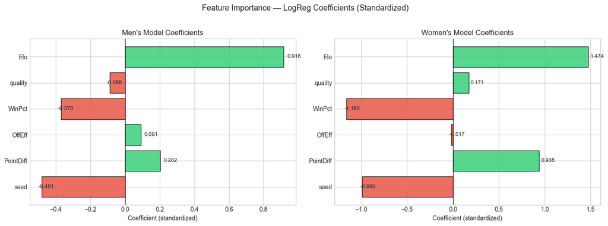

```
Interpretation:
  Green (positive): Higher value for Team 1 → higher P(Team 1 wins)
  Red (negative): Higher value for Team 1 → lower P(Team 1 wins)
  Seed is negative because lower seed number = better team

  Men's intercept:   0.0721
  Women's intercept: 0.1024
  (Intercepts near 0 confirm ~50% base rate — correctly calibrated)
```

1. **Feature correlation structure** — are our features redundant or complementary?
2. **Calibration quality** — does the model output well-calibrated probabilities?
3. **Where the model fails** — which upsets does it miss, and is there a pattern?
4. **Men vs Women dynamics** — why does splitting help so much?
5. **Prediction confidence** — how often is the model sure vs uncertain?

[figure not shown]

[output not shown]

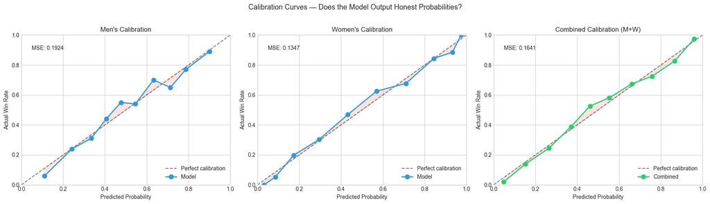

```
Good calibration = points close to the diagonal.
LogReg's native calibration is a key advantage over tree models,
which often need post-hoc recalibration (Platt scaling, isotonic regression).
```

```
======================================================================
  UPSET ANALYSIS — Games Where the Model Was Most Wrong
======================================================================

  MEN'S — Top 10 Worst Predictions (highest squared error):
  Season   Matchup                             Seeds        Pred  Actual    Error
  --------------------------------------------------------------------------
  2012     Missouri vs Norfolk St              (2v15)      0.955       0   0.9127
  2023     F Dickinson vs Purdue               (16v1)      0.053       1   0.8967
  2018     UMBC vs Virginia                    (16v1)      0.057       1   0.8900
  2016     Michigan St vs MTSU                 (2v15)      0.936       0   0.8752
  2022     Kentucky vs St Peter's              (2v15)      0.909       0   0.8266
  2011     Kansas vs VCU                       (1v11)      0.882       0   0.7781
  2013     FGCU vs Georgetown                  (15v2)      0.120       1   0.7745
  2022     Purdue vs St Peter's                (3v15)      0.878       0   0.7717
  2021     Ohio St vs Oral Roberts             (2v15)      0.875       0   0.7652
  2024     Kentucky vs Oakland                 (3v14)      0.874       0   0.7632

  MEN'S Upset rate by seed gap:
    Close (1-3 seed gap): 40.7% upsets, avg MSE = 0.2324 (236 games)
    Medium (4-7): 40.1% upsets, avg MSE = 0.2354 (282 games)
    Large (8-16): 19.5% upsets, avg MSE = 0.1478 (483 games)

  WOMEN'S — Top 10 Worst Predictions (highest squared error):
  Season   Matchup                             Seeds        Pred  Actual    Error
  --------------------------------------------------------------------------
  2013     Baylor vs Louisville                (1v5)       0.940       0   0.8838
  2017     Maryland vs Oregon                  (3v10)      0.936       0   0.8753
  2023     Iowa St vs Toledo                   (5v12)      0.924       0   0.8544
  2014     BYU vs Nebraska                     (12v4)      0.082       1   0.8426
  2022     Baylor vs South Dakota              (2v10)      0.916       0   0.8385
  2016     Maryland vs Washington              (2v7)       0.912       0   0.8313
  2021     Maryland vs Texas                   (2v6)       0.911       0   0.8307
  2017     Duke vs Oregon                      (2v10)      0.911       0   0.8299
  2021     Arizona vs Connecticut              (3v1)       0.089       1   0.8291
  2023     Indiana vs Miami FL                 (1v9)       0.909       0   0.8266

  WOMEN'S Upset rate by seed gap:
    Close (1-3 seed gap): 33.1% upsets, avg MSE = 0.2125 (236 games)
    Medium (4-7): 28.1% upsets, avg MSE = 0.1793 (295 games)
    Large (8-16): 7.4% upsets, avg MSE = 0.0613 (430 games)
```

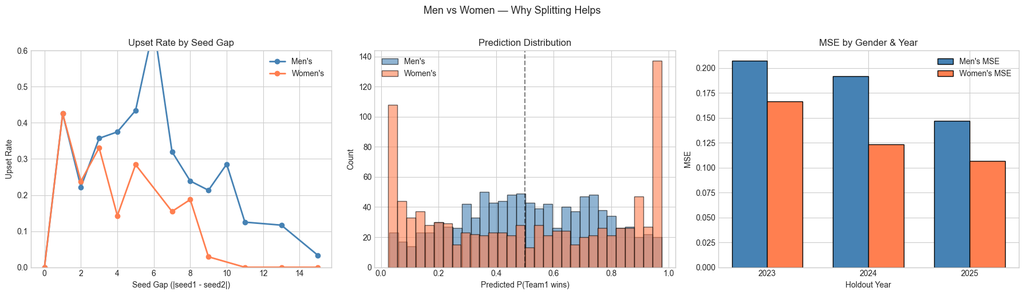

```
Average men's MSE:   0.1819
Average women's MSE: 0.1322
Women are 1.4x more predictable than men.

The women's tournament has fewer upsets because:
  - Larger talent gaps between top and bottom seeds
  - Fewer mid-major Cinderella runs
  - A combined model wastes capacity trying to find one-size-fits-all coefficients
```

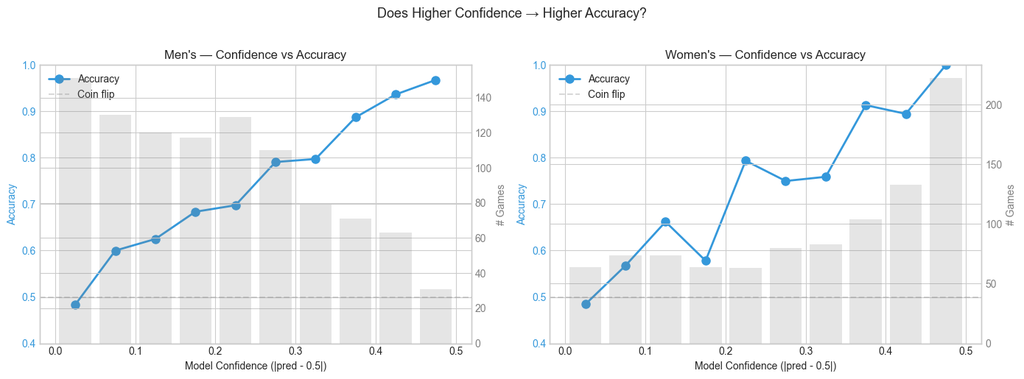

```
Men's:
  High confidence (>80% or <20%): 24.4% of predictions
  Low confidence (40-60%):        28.1% of predictions
  Avg confidence: 0.201

Women's:
  High confidence (>80% or <20%): 56.4% of predictions
  Low confidence (40-60%):        14.4% of predictions
  Avg confidence: 0.302
```

### Paths to Improvement

Based on the analysis above, there are a few concrete directions that could squeeze out more MSE improvement. Each idea is tested below with multi-year holdout validation.

#### Ideas with merit:

1. **Seed-specific confidence adjustment** — the model treats all seed matchups the same, but 1v16 games are ~99% predictable while 8v9 games are coin flips. Adjusting confidence by round/slot could help.
2. **Ensemble averaging** — average predictions from the top 2-3 experiments. Ensemble diversity can reduce variance if models make different errors.
3. **Conference tournament performance** — a team's March results (conference tournament) are a strong recency signal not captured by regular season stats.
4. **Per-round modeling** — early rounds (1v16, 2v15) are highly predictable; later rounds (Elite 8, Final Four) are more chaotic. A round-aware model could adjust confidence accordingly.
5. **Temporal weighting** — weight recent seasons more heavily in training, since the game evolves (3-point revolution, transfer portal).

```
============================================================
  Experiment: Ensemble: LR+XGB Split
  Average of Split LR(top4q_elo) and Split XGB-men/LR-women(top4q_elo)
============================================================
  2023: MSE=0.188075, Acc=70.9%  (134 games)
  2024: MSE=0.161226, Acc=72.4%  (134 games)
  2025: MSE=0.129037, Acc=82.8%  (134 games)
  Average MSE: 0.159446
============================================================

============================================================
  Experiment: Ensemble: Elo+NoElo Split
  Average of Split LR(top4q_elo) and Split LR(top4q) — feature diversity
============================================================
  2023: MSE=0.186863, Acc=68.7%  (134 games)
  2024: MSE=0.158884, Acc=76.1%  (134 games)
  2025: MSE=0.133379, Acc=84.3%  (134 games)
  Average MSE: 0.159708
============================================================
```

```
{2023: {'mse': 0.1868626282722776,
  'accuracy': np.float64(0.6865671641791045),
  'n_games': 134},
 2024: {'mse': 0.15888389955971177,
  'accuracy': np.float64(0.7611940298507462),
  'n_games': 134},
 2025: {'mse': 0.13337892954927769,
  'accuracy': np.float64(0.8432835820895522),
  'n_games': 134}}
```

```
============================================================
  Experiment: Split+LinearDecay
  Split LR(top4q_elo) with linear recency weights (recent seasons weighted 1.5x)
============================================================
  2023: MSE=0.190307, Acc=70.9%  (134 games)
  2024: MSE=0.161905, Acc=72.4%  (134 games)
  2025: MSE=0.130270, Acc=83.6%  (134 games)
  Average MSE: 0.160828
============================================================

============================================================
  Experiment: Split+ExpDecay
  Split LR(top4q_elo) with exponential recency weights (e^0.15*(s-holdout))
============================================================
  2023: MSE=0.190690, Acc=69.4%  (134 games)
  2024: MSE=0.161884, Acc=73.9%  (134 games)
  2025: MSE=0.132076, Acc=81.3%  (134 games)
  Average MSE: 0.161550
============================================================
```

```
{2023: {'mse': 0.19069021283802828,
  'accuracy': np.float64(0.6940298507462687),
  'n_games': 134},
 2024: {'mse': 0.16188375857061957,
  'accuracy': np.float64(0.7388059701492538),
  'n_games': 134},
 2025: {'mse': 0.13207649769446161,
  'accuracy': np.float64(0.8134328358208955),
  'n_games': 134}}
```

```
============================================================
  Experiment: Split: M(Top4+Q+Elo) + W(Seed+Elo)
  Men: full top4+quality+Elo, Women: just seed+Elo (minimal)
============================================================
  2023: MSE=0.188296, Acc=70.9%  (134 games)
  2024: MSE=0.158297, Acc=74.6%  (134 games)
  2025: MSE=0.133816, Acc=82.1%  (134 games)
  Average MSE: 0.160136
============================================================

============================================================
  Experiment: Split: M(Top4+Q+Elo) + W(Top4)
  Men: full top4+quality+Elo, Women: just top4 (no derived metrics)
============================================================
  2023: MSE=0.185289, Acc=71.6%  (134 games)
  2024: MSE=0.158714, Acc=75.4%  (134 games)
  2025: MSE=0.135566, Acc=84.3%  (134 games)
  Average MSE: 0.159856
============================================================

============================================================
  Experiment: Split: M(Top4+Q+Elo+Massey) + W(Top4+Q+Elo)
  Men: top4+quality+Elo+Massey (men-only data so Massey is clean), Women: top4+quality+Elo
============================================================
  2023: MSE=0.190849, Acc=69.4%  (134 games)
  2024: MSE=0.162473, Acc=72.4%  (134 games)
  2025: MSE=0.131132, Acc=84.3%  (134 games)
  Average MSE: 0.161485
============================================================
```

```
{2023: {'mse': 0.19084930335796071,
  'accuracy': np.float64(0.6940298507462687),
  'n_games': 134},
 2024: {'mse': 0.16247308043670525,
  'accuracy': np.float64(0.7238805970149254),
  'n_games': 134},
 2025: {'mse': 0.13113235798860878,
  'accuracy': np.float64(0.8432835820895522),
  'n_games': 134}}
```

```
============================================================
  Experiment: Split+Shrink α=0.05
  Split LR(top4q_elo) with 5% shrinkage toward 0.5
============================================================
  2023: MSE=0.189016, Acc=71.6%  (134 games)
  2024: MSE=0.162059, Acc=71.6%  (134 games)
  2025: MSE=0.132428, Acc=84.3%  (134 games)
  Average MSE: 0.161168
============================================================

============================================================
  Experiment: Split+Shrink α=0.1
  Split LR(top4q_elo) with 10% shrinkage toward 0.5
============================================================
  2023: MSE=0.188759, Acc=71.6%  (134 games)
  2024: MSE=0.163101, Acc=71.6%  (134 games)
  2025: MSE=0.135177, Acc=84.3%  (134 games)
  Average MSE: 0.162346
============================================================

============================================================
  Experiment: Split+Shrink α=0.15
  Split LR(top4q_elo) with 15% shrinkage toward 0.5
============================================================
  2023: MSE=0.188888, Acc=71.6%  (134 games)
  2024: MSE=0.164540, Acc=71.6%  (134 games)
  2025: MSE=0.138308, Acc=84.3%  (134 games)
  Average MSE: 0.163912
============================================================

============================================================
  Experiment: Split+Shrink α=0.2
  Split LR(top4q_elo) with 20% shrinkage toward 0.5
============================================================
  2023: MSE=0.189401, Acc=71.6%  (134 games)
  2024: MSE=0.166379, Acc=71.6%  (134 games)
  2025: MSE=0.141821, Acc=84.3%  (134 games)
  Average MSE: 0.165867
============================================================
```

```
======================================================================
  FULL LEADERBOARD — Including Improvement Experiments
======================================================================

================================================================================
  EXPERIMENT LEADERBOARD (sorted by avg MSE, lower = better)
================================================================================
                                            name                                                                              description  MSE_2023  MSE_2024  MSE_2025  MSE_avg
                                 Women Top4 (LR)                                                              LogReg on top4 (women only)  0.159605  0.123135  0.119020 0.133920
                           Women Top4+Q+Elo (LR)                                              LogReg on top4 + quality + Elo (women only)  0.168395  0.128587  0.108081 0.135021
                               Women Top4+Q (LR)                                                    LogReg on top4 + quality (women only)  0.170400  0.119802  0.114894 0.135032
                                Top4+Q+Elo (XGB)                                                  XGBoost depth=2 on top4 + quality + Elo  0.187155  0.159482  0.130628 0.159088
                          Ensemble: LR+XGB Split                     Average of Split LR(top4q_elo) and Split XGB-men/LR-women(top4q_elo)  0.188075  0.161226  0.129037 0.159446
                       Ensemble: Elo+NoElo Split                   Average of Split LR(top4q_elo) and Split LR(top4q) — feature diversity  0.186863  0.158884  0.133379 0.159708
                  Split: M(Top4+Q+Elo) + W(Top4)                        Men: full top4+quality+Elo, Women: just top4 (no derived metrics)  0.185289  0.158714  0.135566 0.159856
              Split: M(Top4+Q+Elo) + W(Seed+Elo)                               Men: full top4+quality+Elo, Women: just seed+Elo (minimal)  0.188296  0.158297  0.133816 0.160136
      Split: M(Top4+Q+Elo LR) + W(Top4+Q+Elo LR)                                     Men: LR top4+quality+Elo, Women: LR top4+quality+Elo  0.189684  0.161440  0.130096 0.160407
          Split: M(Top4+Q+Elo LR) + W(Top4+Q LR)                                Men: LR top4+quality+Elo, Women: LR top4+quality (no Elo)  0.190687  0.157047  0.133503 0.160412
                                   Top4+Elo (LR)                                       LogReg on seed + PointDiff + OffEff + WinPct + Elo  0.188780  0.166325  0.126699 0.160601
                               Split+LinearDecay           Split LR(top4q_elo) with linear recency weights (recent seasons weighted 1.5x)  0.190307  0.161905  0.130270 0.160828
                                 Top4+Q+Elo (LR)                                                           LogReg on top4 + quality + Elo  0.189025  0.167249  0.127048 0.161107
                             Split+Shrink α=0.05                                         Split LR(top4q_elo) with 5% shrinkage toward 0.5  0.189016  0.162059  0.132428 0.161168
         Split: M(Top4+Q+SOS+FG LR) + W(Top4 LR)                                           Men: LR top4+quality+SOS+FGPct, Women: LR top4  0.185687  0.159064  0.138863 0.161205
             Split: M(Top4+Q XGB) + W(Top4+Q LR)                                    Men: XGB depth=2 top4+quality, Women: LR top4+quality  0.185163  0.160651  0.138033 0.161282
              Split: M(Top4+Q LR) + W(Top4+Q LR)                              Separate LR models — men: top4+quality, women: top4+quality  0.186508  0.158479  0.139105 0.161364
     Split: M(Top4+Q+Elo+Massey) + W(Top4+Q+Elo) Men: top4+quality+Elo+Massey (men-only data so Massey is clean), Women: top4+quality+Elo  0.190849  0.162473  0.131132 0.161485
```

[output cut: 35 more lines]

### Final Optimization Sweep

Quick targeted experiments on the remaining untested levers:

1. **Seed × Elo interaction** — does the relationship between Elo and winning change by seed tier?
2. **Per-gender C tuning** — men's and women's might need different regularization
3. **Seed benchmark blend** — average model predictions with the simple seed-based benchmark

```
============================================================
  Experiment: Split+Interaction(seed×Elo)
  top4q_elo + seed×Elo interaction
============================================================
  2023: MSE=0.188549, Acc=70.9%  (134 games)
  2024: MSE=0.160203, Acc=72.4%  (134 games)
  2025: MSE=0.129123, Acc=84.3%  (134 games)
  Average MSE: 0.159292
============================================================

============================================================
  Experiment: Split+Interactions(top3)
  top4q_elo + pairwise interactions of seed, Elo, PointDiff
============================================================
  2023: MSE=0.188558, Acc=70.1%  (134 games)
  2024: MSE=0.159337, Acc=71.6%  (134 games)
  2025: MSE=0.128483, Acc=84.3%  (134 games)
  Average MSE: 0.158793
============================================================

--- Per-Gender C Tuning ---

============================================================
  Experiment: Split C(M=0.5, W=2.0)
  Split LR with C=0.5 for men, C=2.0 for women
============================================================
  2023: MSE=0.189705, Acc=70.9%  (134 games)
  2024: MSE=0.161874, Acc=72.4%  (134 games)
  2025: MSE=0.130221, Acc=84.3%  (134 games)
  Average MSE: 0.160600
============================================================

============================================================
  Experiment: Split C(M=2.0, W=0.5)
  Split LR with C=2.0 for men, C=0.5 for women
============================================================
  2023: MSE=0.189437, Acc=71.6%  (134 games)
  2024: MSE=0.160798, Acc=72.4%  (134 games)
  2025: MSE=0.130088, Acc=85.1%  (134 games)
  Average MSE: 0.160108
```

[output cut: 127 more lines]

```
                             Split+Shrink α=0.15                                        Split LR(top4q_elo) with 15% shrinkage toward 0.5  0.188888  0.164540  0.138308 0.163912
                          Split+SeedBlend(α=0.1)                                                     Blend 90% model + 10% seed-diff prob  0.189926  0.166205  0.140029 0.165386
                              Split+Shrink α=0.2                                        Split LR(top4q_elo) with 20% shrinkage toward 0.5  0.189401  0.166379  0.141821 0.165867
                                  Seed Only (LR)                                                                 LogReg on Diff_seed only  0.190180  0.164201  0.143248 0.165876
                              Top4+Q (LR C=0.01)                                                          LogReg C=0.01 on top4 + quality  0.188344  0.168637  0.144676 0.167219
                                   All Diff (LR)                                                           LogReg on all 20 diff features  0.188309  0.169386  0.144699 0.167465
                          Split+SeedBlend(α=0.2)                                                     Blend 80% model + 20% seed-diff prob  0.194845  0.175718  0.154537 0.175033
                             Men Top4+Q+Elo (LR)                                                LogReg on top4 + quality + Elo (men only)  0.210973  0.194293  0.152111 0.185793
                                   Men Top4 (LR)                                                                LogReg on top4 (men only)  0.204697  0.196148  0.159055 0.186633
                                Men Top4+Q (XGB)                                             XGBoost depth=2 on top4 + quality (men only)  0.199927  0.201500  0.161173 0.187533
                                 Men Top4+Q (LR)                                                      LogReg on top4 + quality (men only)  0.202617  0.197156  0.163315 0.187696
                       Men Top4+Q+Elo+Coach (LR)                                     LogReg on top4 + quality + Elo + CoachExp (men only)  0.217449  0.194727  0.153487 0.188554
                                Men Top6+Q (XGB)                                             XGBoost depth=2 on top6 + quality (men only)  0.202861  0.201760  0.162950 0.189190
                          Split+SeedBlend(α=0.3)                                                     Blend 70% model + 30% seed-diff prob  0.204414  0.189955  0.173587 0.189319
                          Men Top4+Q+Massey (LR)                                             LogReg on top4 + quality + massey (men only)  0.209355  0.203494  0.165678 0.192842
```

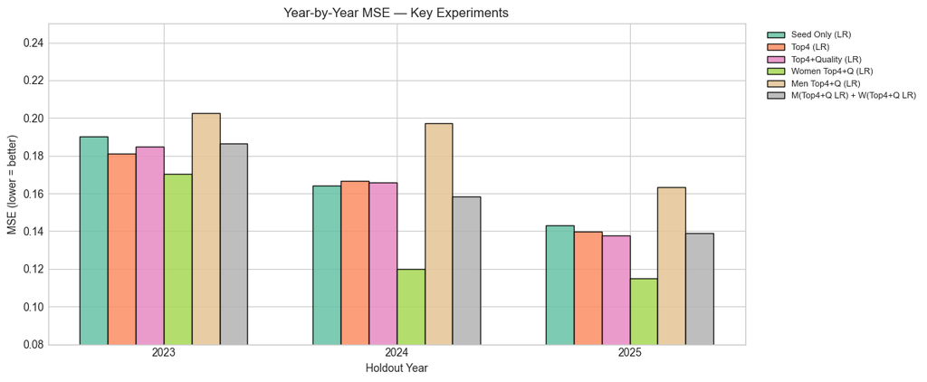

```
Key takeaway: Women-only model is consistently the best (~0.12–0.17).
The split strategy brings overall MSE down by pairing it with a decent men's model.
```

```
Men's predictions: 66,430 matchups
Women's predictions: 65,703 matchups
Submission saved to ../output/submission_refined.csv (132133 rows)
Pred range: [0.0250, 0.9750]
Pred mean: 0.5113
```

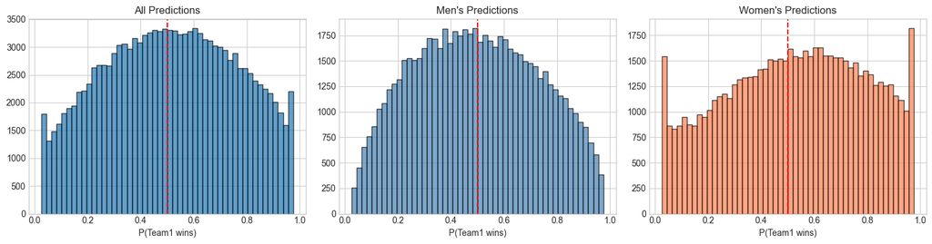

```
Submission stats:
  Mean: 0.5113
  Std:  0.2472
  Min:  0.0250
  Max:  0.9750
```

```
============================================================
  2026 Matchup Predictions — Men's
============================================================
  Auburn vs Duke: Duke wins (66.7%)
  Houston vs Tennessee: Houston wins (62.9%)
  Alabama vs Florida: Florida wins (62.5%)
  Iowa St vs Marquette: Iowa St wins (79.7%)
  Kansas vs St John's: St John's wins (56.1%)
  Duke vs Houston: Duke wins (55.4%)

============================================================
  2026 Matchup Predictions — Women's
============================================================
  South Carolina vs UCLA: South Carolina wins (56.7%)
  LSU vs Texas: LSU wins (58.1%)
  Connecticut vs Notre Dame: Connecticut wins (88.8%)
  South Carolina vs USC: South Carolina wins (74.8%)
```

## Step 5: Export Models & Bracket App

Export trained models and team features to `models/` for the interactive bracket predictor app.

**To run the bracket app:**

```
python -m src.export_models   # Train & save models (if not already done)
streamlit run app.py           # Launch interactive bracket filler
```

```
============================================================
  TRAINING FINAL MODELS FOR BRACKET APP
============================================================

[1/5] Loading data...
  Regular season: 174,206 games
  Tournament: 1,962 games
  Seeds: 4,370 entries

[2/5] Computing features...
  Team features: 11,969 team-seasons, 38 columns

[3/5] Building training matchups...
  Men's training games: 1001
  Women's training games: 961

[4/5] Training models...
  Men's model coefficients: {'Diff_seed': np.float64(-0.481), 'Diff_PointDiff': np.float64(0.202), 'Diff_OffEff': np.float64(0.091), 'Diff_WinPct': np.float64(-0.37), 'Diff_quality': np.float64(-0.088), 'Diff_Elo': np.float64(0.916)}
  Women's model coefficients: {'Diff_seed': np.float64(-0.99), 'Diff_PointDiff': np.float64(0.938), 'Diff_OffEff': np.float64(-0.017), 'Diff_WinPct': np.float64(-1.16), 'Diff_quality': np.float64(0.171), 'Diff_Elo': np.float64(1.474)}

[5/5] Saving artifacts...

  Saved to C:\Users\JonMa\OneDrive\portfolio\Madness\models/:
    config.json                    (0.5 KB)
    men_model.pkl                  (0.7 KB)
    men_scaler.pkl                 (0.5 KB)
    team_features.pkl              (3554.4 KB)
    teams.pkl                      (27.8 KB)
    women_model.pkl                (0.7 KB)
    women_scaler.pkl               (0.5 KB)

============================================================
  EXPORT COMPLETE — ready for bracket app!
============================================================

Features: ['Diff_seed', 'Diff_PointDiff', 'Diff_OffEff', 'Diff_WinPct', 'Diff_quality', 'Diff_Elo']
Ready to run: streamlit run app.py
```

## Summary & Decision Log

### What we tried and what worked

[output not shown]

### Why simple beats complex

1. **~1,900 tournament games total (2010–2025)** — not enough signal for deep models
2. **The selection committee already did the ML** — seeds encode SOS, record, eye test
3. **MSE punishes overconfidence** — a conservative 0.6 prediction beats a wrong 0.9 prediction
4. **Feature differences are linear** — seed diff → win prob is nearly sigmoid-shaped, perfect for LogReg

### Why Elo works

- **Captures recency**: late-season losses hurt more than early-season ones
- **Weights opponent quality**: beating a 1600-Elo team > beating a 1300-Elo team
- **Carries over between seasons**: sustained excellence gets credit (75% carry-over)
- **Margin-of-victory aware**: blowouts count more (with `log(1+MOV)` diminishing returns)
- **Largest coefficient in both models**: Men (0.92), Women (1.47) — model's strongest signal

### Bracket App

Run `streamlit run app.py` for an interactive bracket predictor:

- Auto-fill brackets using trained models (deterministic or probabilistic)
- Manual overrides for any game
- Head-to-head matchup explorer with win probabilities
- Works with any past season or the 2026 tournament (once seeds are released)